# Interplay between glycolytic and acetate metabolisms in *Escherichia coli*

### 4.4. Acetate flux as function of glycolytic activity

Model predictions.

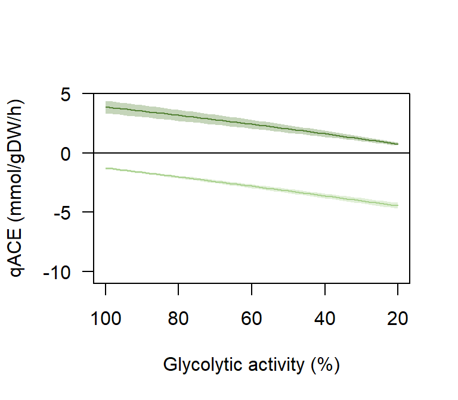

```r
x <- seq(20, 100, by=2)

plot_with_ci_5(simulation_results, 1, x, "Values[v_ace_net]", col="#548235", las=1, lwd=1.2, ylim=c(-11,5), yaxs="i", xlab="Glycolytic activity (%)", ylab="qACE (mmol/gDW/h)")
abline(h=0)

plot_with_ci_5(simulation_results, 2, x, "Values[v_ace_net]", col="#A9D18E", add_to_plot = TRUE, lwd=1.2)
```

Save Source data.

```r
data_to_save <- cbind(apply(simulation_results[,,1,"Values[v_ace_net]"], 2, mean),
                      apply(simulation_results[,,1,"Values[v_ace_net]"], 2, sd),
                      apply(simulation_results[,,2,"Values[v_ace_net]"], 2, mean),
                      apply(simulation_results[,,2,"Values[v_ace_net]"], 2, sd))

colnames(data_to_save) <- c("mean_ace_0", "sd_ace_0", "mean_ace_30", "sd_ace_30")
rownames(data_to_save) <- glc_vmax/max(glc_vmax)*100

write.csv(data_to_save, "results/SourceData/Figure 2/2B/data_2B.csv", quote=FALSE)
```

Experimental validation.

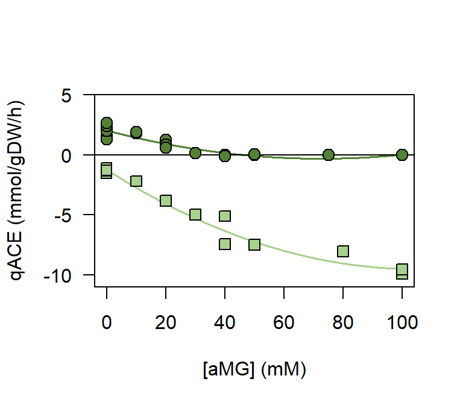

```r
# fit polynomial model
polyfit_no_ace <- polynomial_model(exp_data[filter,], "aMG", "qACE", 2, lpred=seq(0,100,by=0.1))
polyfit_ace <- polynomial_model(exp_data[!filter,], "aMG", "qACE", 2, lpred=seq(0,100,by=0.1))

# plot fit and confidence intervals
plot(polyfit_no_ace$fited_curve_x, polyfit_no_ace$fited_curve_y, ylim=c(-11,5), las=1, yaxs="i", ylab="qACE (mmol/gDW/h)", xlab="[aMG] (mM)", col="#548235", lwd=1.5, type="l")

abline(h=0)

lines(polyfit_ace$fited_curve_x, polyfit_ace$fited_curve_y, col="#A9D18E", lwd=1.5)
#polygon(c(polyfit_no_ace$fited_curve_x, rev(polyfit_no_ace$fited_curve_x)), c(polyfit_no_ace$confidence_intervals[,1], rev(polyfit_no_ace$confidence_intervals[,2])), col=adjustcolor("#548235", alpha.f=0.4), border = NA)
#polygon(c(polyfit_ace$fited_curve_x, rev(polyfit_ace$fited_curve_x)), c(polyfit_ace$confidence_intervals[,1], rev(polyfit_ace$confidence_intervals[,2])), col=adjustcolor("#A9D18E", alpha.f=0.4), border = NA)

# plot experimental data
points(exp_data$aMG[filter], exp_data$qACE[filter], lwd=1.0, pch=21, bg="#548235", col="black", cex=1.4)
points(exp_data$aMG[!filter], exp_data$qACE[!filter], pch=22, bg="#A9D18E", col="black", cex=1.4, lwd=1.0)
```

Save Source data.

```r
data_to_save <- exp_data[,c("strain", "carbon_source", "aMG", "ACE", "qACE", "source")]
write.csv(data_to_save, "results/SourceData/Figure 2/2F/data_2F.csv", quote=FALSE)
```

### 4.5. Growth rate as function of glycolytic activity

Model predictions.

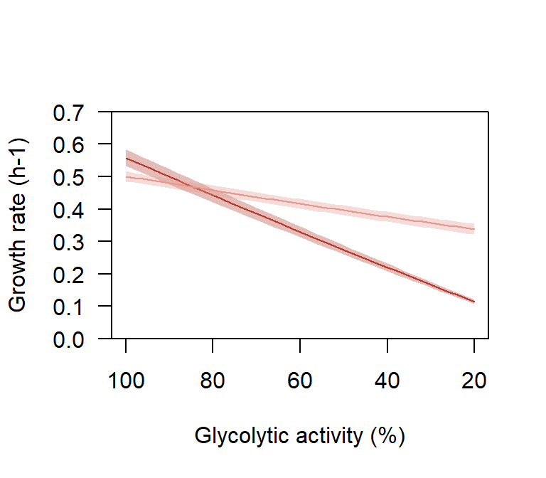

```r
x <- seq(20, 100, by=2)

plot_with_ci_5(simulation_results, 1, x, "Values[v_growth_rate]", col = "#B63A2D", las = 1, lwd = 1.2, ylim = c(0, 0.7), xlab = "Glycolytic activity (%)", ylab = "Growth rate (h-1)", yaxs="i")

plot_with_ci_5( simulation_results, 2, x, "Values[v_growth_rate]", col = "#E49890", add_to_plot = TRUE, lwd = 1.2)
```

Save Source data.

```r
data_to_save <- cbind(apply(simulation_results[,,1,"Values[v_growth_rate]"], 2, mean),
                      apply(simulation_results[,,1,"Values[v_growth_rate]"], 2, sd),
                      apply(simulation_results[,,2,"Values[v_growth_rate]"], 2, mean),
                      apply(simulation_results[,,2,"Values[v_growth_rate]"], 2, sd))

colnames(data_to_save) <- c("mean_ace_0", "sd_ace_0", "mean_ace_30", "sd_ace_30")
rownames(data_to_save) <- glc_vmax/max(glc_vmax)*100

write.csv(data_to_save, "results/SourceData/Figure 2/2C/data_2C.csv", quote=FALSE)
```

Experimental validation.

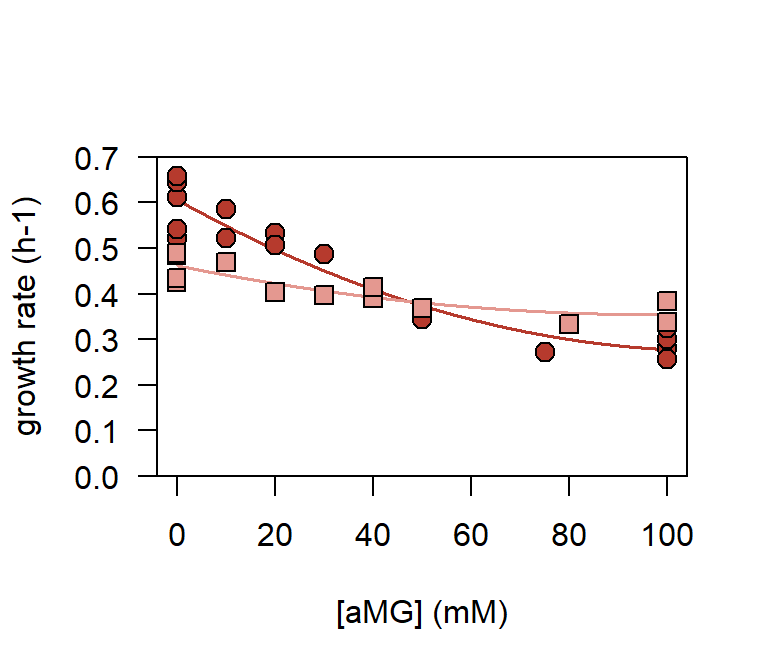

```r
# fit polynomial model
polyfit_no_ace <- polynomial_model(exp_data[filter,], "aMG", "mu", 2, lpred=seq(0,100,by=0.1))
polyfit_ace <- polynomial_model(exp_data[!filter,], "aMG", "mu", 2, lpred=seq(0,100,by=0.1))

# plot fit and confidence intervals
plot(polyfit_no_ace$fited_curve_x, polyfit_no_ace$fited_curve_y, ylim=c(0,0.7), las=1, yaxs="i", ylab="growth rate (h-1)", xlab="[aMG] (mM)", col="#B63A2D", lwd=1.5, type="l")
lines(polyfit_ace$fited_curve_x, polyfit_ace$fited_curve_y, col="#E49890", lwd=1.5)
#polygon(c(polyfit_no_ace$fited_curve_x, rev(polyfit_no_ace$fited_curve_x)), c(polyfit_no_ace$confidence_intervals[,1], rev(polyfit_no_ace$confidence_intervals[,2])), col=adjustcolor("#B63A2D", alpha.f=0.4), border = NA)
#polygon(c(polyfit_ace$fited_curve_x, rev(polyfit_ace$fited_curve_x)), c(polyfit_ace$confidence_intervals[,1], rev(polyfit_ace$confidence_intervals[,2])), col=adjustcolor("#E49890", alpha.f=0.4), border = NA)

# plot experimental data
points(exp_data$aMG[filter], exp_data$mu[filter], lwd=1.0, pch=21, bg="#B63A2D", col="black", cex=1.4)
points(exp_data$aMG[!filter], exp_data$mu[!filter], pch=22, bg="#E49890", col="black", cex=1.4, lwd=1.0)
```

Save Source data.

```r
data_to_save <- exp_data[,c("strain", "carbon_source", "aMG", "ACE", "mu", "source")]
write.csv(data_to_save, "results/SourceData/Figure 2/2G/data_2G.csv", quote=FALSE)
```

### 4.6. Total carbon uptake

Model predictions.

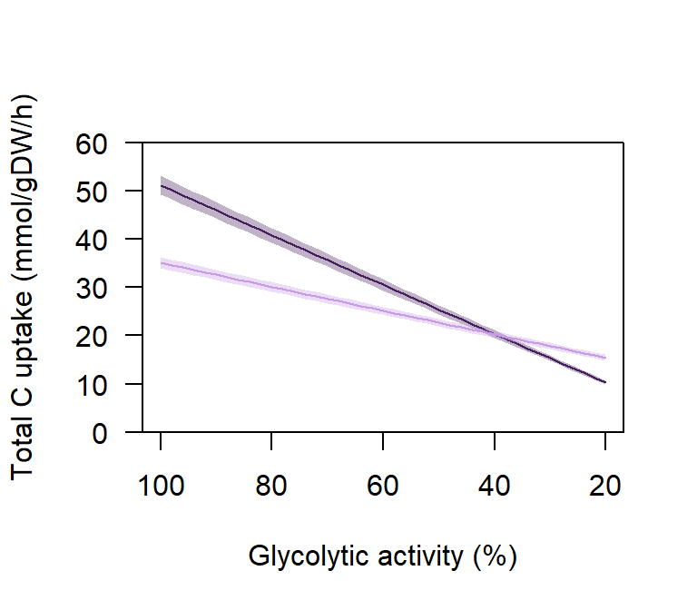

```r
x <- seq(20, 100, by=2)

plot_with_ci_5(simulation_results, 1, x, "Total_C_uptake", col="#451E5D", las=1, lwd=1.2, ylim=c(0,60), xlab="Glycolytic activity (%)", ylab="Total C uptake (mmol/gDW/h)", yaxs="i")

plot_with_ci_5(simulation_results, 2, x, "Total_C_uptake", col="#C89CE4", add_to_plot = TRUE, lwd=1.2)
```

Save Source data.

```r
data_to_save <- cbind(apply(simulation_results[,,1,"Total_C_uptake"], 2, mean),
                      apply(simulation_results[,,1,"Total_C_uptake"], 2, sd),
                      apply(simulation_results[,,2,"Total_C_uptake"], 2, mean),
                      apply(simulation_results[,,2,"Total_C_uptake"], 2, sd))

colnames(data_to_save) <- c("mean_ace_0", "sd_ace_0", "mean_ace_30", "sd_ace_30")
rownames(data_to_save) <- glc_vmax/max(glc_vmax)*100

write.csv(data_to_save, "results/SourceData/Figure 2/2D/data_2D.csv", quote=FALSE)
```

Experimental validation.

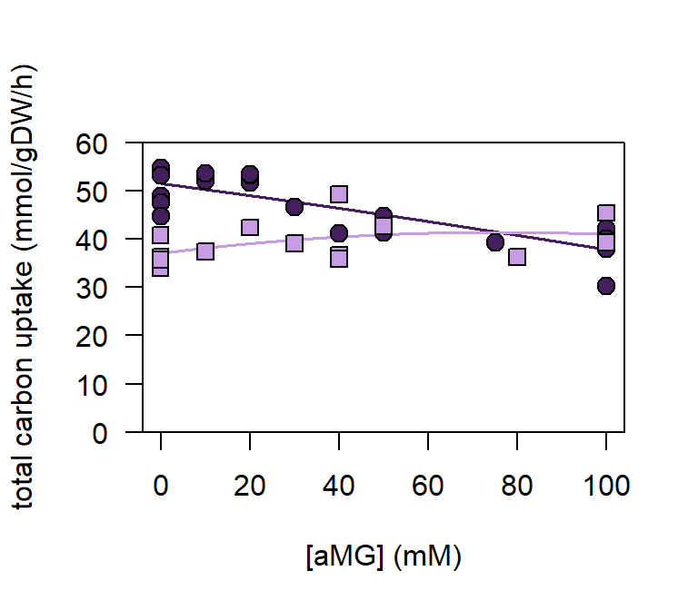

```r
# fit polynomial model
polyfit_no_ace <- polynomial_model(exp_data[filter,], "aMG", "Ctotal", 2, lpred=seq(0,100,by=0.1))
polyfit_ace <- polynomial_model(exp_data[!filter,], "aMG", "Ctotal", 2, lpred=seq(0,100,by=0.1))

# plot fit and confidence intervals
plot(polyfit_no_ace$fited_curve_x, polyfit_no_ace$fited_curve_y, ylim=c(0, 60), las=1, yaxs="i", ylab="total carbon uptake (mmol/gDW/h)", xlab="[aMG] (mM)", col="#451E5D", lwd=1.5, type="l")
lines(polyfit_ace$fited_curve_x, polyfit_ace$fited_curve_y, col="#C89CE4", lwd=1.5)
#polygon(c(polyfit_no_ace$fited_curve_x, rev(polyfit_no_ace$fited_curve_x)), c(polyfit_no_ace$confidence_intervals[,1], rev(polyfit_no_ace$confidence_intervals[,2])), col=adjustcolor("#451E5D", alpha.f=0.4), border = NA)
#polygon(c(polyfit_ace$fited_curve_x, rev(polyfit_ace$fited_curve_x)), c(polyfit_ace$confidence_intervals[,1], rev(polyfit_ace$confidence_intervals[,2])), col=adjustcolor("#C89CE4", alpha.f=0.4), border = NA)

# plot experimental data
points(exp_data$aMG[filter], exp_data$Ctotal[filter], lwd=1.0, pch=21, bg="#451E5D", col="black", cex=1.4)
points(exp_data$aMG[!filter], exp_data$Ctotal[!filter], pch=22, bg="#C89CE4", col="black", cex=1.4, lwd=1.0)
```

Save Source data.

```r
data_to_save <- exp_data[,c("strain", "carbon_source", "aMG", "ACE", "Ctotal", "source")]
write.csv(data_to_save, "results/SourceData/Figure 2/2H/data_2H.csv", quote=FALSE)
```

Total carbon uptake as function of glucose uptake rate.

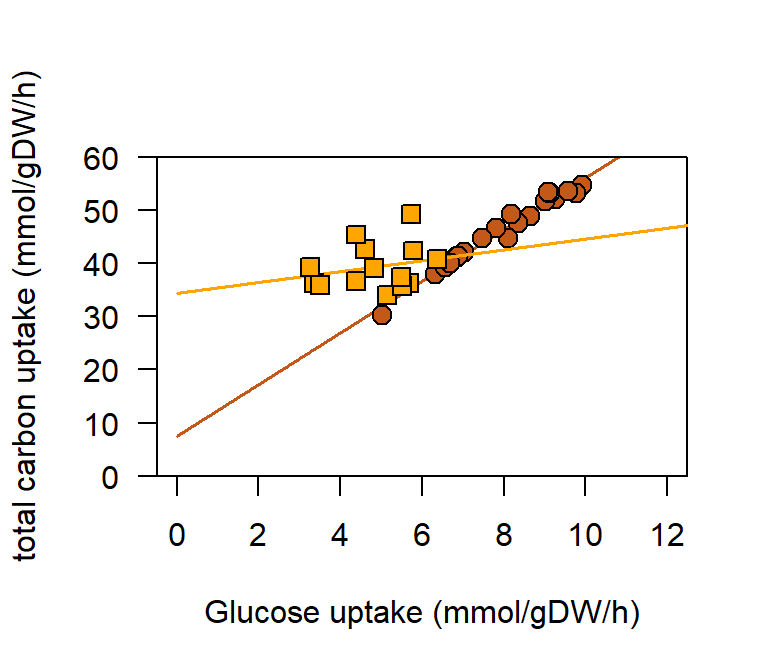

```r
# fit polynomial model
polyfit <- polynomial_model(exp_data[filter,], "qGLC", "Ctotal", 1, lpred=seq(0,12,by=0.01))

# plot fit
plot(polyfit$fited_curve_x, polyfit$fited_curve_y, ylim=c(0, 60), xlim=c(0,12), las=1, yaxs="i", ylab="total carbon uptake (mmol/gDW/h)", xlab="Glucose uptake (mmol/gDW/h)", col="#C45818", lwd=1.5, type="l")

# plot experimental data
points(exp_data$qGLC[filter], exp_data$Ctotal[filter], lwd=1.0, pch=21, bg="#C45818", col="black", cex=1.4)

polyfit <- polynomial_model(exp_data[!filter,], "qGLC", "Ctotal", 1, lpred=seq(0,15,by=0.01))

lines(polyfit$fited_curve_x, polyfit$fited_curve_y, col="#FEA500", lwd=1.5)

points(exp_data$qGLC[!filter], exp_data$Ctotal[!filter], lwd=1.0, pch=22, bg="#FEA500", col="black", cex=1.4)
```

Save Source data.

```r
data_to_save <- exp_data[,c("strain", "carbon_source", "aMG", "ACE", "Ctotal", "qGLC", "source")]
write.csv(data_to_save, "results/SourceData/Figure 2/2K/data_2K.csv", quote=FALSE)
```

Growth rate as function of glucose uptake rate.

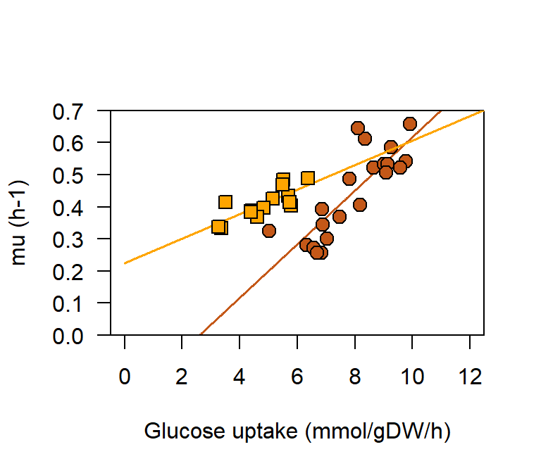

```r
# fit polynomial model
polyfit <- polynomial_model(exp_data[filter,], "qGLC", "mu", 1, lpred=seq(0,12,by=0.01))

# plot fit
plot(polyfit$fited_curve_x, polyfit$fited_curve_y, ylim=c(0, 0.7), xlim=c(0,12), las=1, yaxs="i", ylab="mu (h-1)", xlab="Glucose uptake (mmol/gDW/h)", col="#C45818", lwd=1.5, type="l")

# plot experimental data
points(exp_data$qGLC[filter], exp_data$mu[filter], lwd=1.0, pch=21, bg="#C45818", col="black", cex=1.4)

polyfit <- polynomial_model(exp_data[!filter,], "qGLC", "mu", 1, lpred=seq(0,15,by=0.01))

lines(polyfit$fited_curve_x, polyfit$fited_curve_y, col="#FEA500", lwd=1.5)

points(exp_data$qGLC[!filter], exp_data$mu[!filter], lwd=1.0, pch=22, bg="#FEA500", col="black", cex=1.4)
```

Save Source data.

```r
data_to_save <- exp_data[,c("strain", "carbon_source", "aMG", "ACE", "mu", "qGLC", "source")]
write.csv(data_to_save, "results/SourceData/Figure 2/2L/data_2L.csv", quote=FALSE)
```

### 4.7. Contribution of acetate to carbon uptake

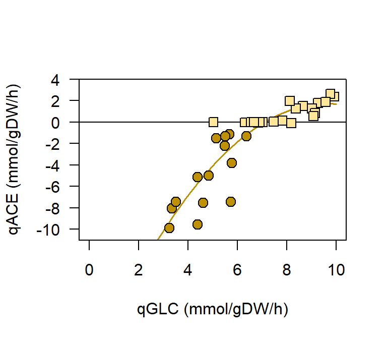

```r
# fit polynomial model
polyfit <- polynomial_model(exp_data, "qGLC", "qACE", 2, lpred=seq(0,10,by=0.01))

# note: to avoid a bug on windows platforms when the plotted polygon is bigger than the plot, see https://bugs.r-project.org/show_bug.cgi?id=18219
#polyfit$confidence_intervals[polyfit$confidence_intervals > 3] <- 3
#polyfit$confidence_intervals[polyfit$confidence_intervals < -11] <- -11
# plot fit and confidence intervals
plot(polyfit$fited_curve_x, polyfit$fited_curve_y, ylim=c(-11, 4), las=1, yaxs="i", ylab="qACE (mmol/gDW/h)", xlab="qGLC (mmol/gDW/h)", col="#BF9000", lwd=1.5, type="l", yaxs="i")

abline(h=0)

#polygon(c(polyfit$fited_curve_x, rev(polyfit$fited_curve_x)), c(polyfit$confidence_intervals[,1], rev(polyfit$confidence_intervals[,2])), col=adjustcolor("#BF9000", alpha.f=0.4), border = NA)
# plot experimental data
points(exp_data$qGLC[filter], exp_data$qACE[filter], lwd=1.0, pch=22, bg="#FFE699", col="black", cex=1.4)
points(exp_data$qGLC[!filter], exp_data$qACE[!filter], lwd=1.0, pch=21, bg="#BF9000", col="black", cex=1.4)
```

Save Source data.

```r
data_to_save <- exp_data[,c("strain", "carbon_source", "qACE", "Ctotal", "source")]
write.csv(data_to_save, "results/SourceData/Figure 2/2I/data_2I.csv", quote=FALSE)
```

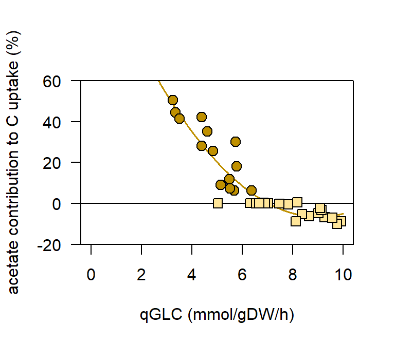

```r
# fit polynomial model
polyfit <- polynomial_model(exp_data, "qGLC", "contribution_acetate", 2, lpred=seq(0,10,by=0.01))

# note: to avoid a bug on windows platforms when the plotted polygon is bigger than the plot, see https://bugs.r-project.org/show_bug.cgi?id=18219
#polyfit$confidence_intervals[polyfit$confidence_intervals > 60] <- 60
#polyfit$confidence_intervals[polyfit$confidence_intervals < -20] <- -20
# plot fit and confidence intervals
plot(polyfit$fited_curve_x, polyfit$fited_curve_y, ylim=c(-20, 60), las=1, yaxs="i", ylab="acetate contribution to C uptake (%)", xlab="qGLC (mmol/gDW/h)", col="#BF9000", lwd=1.5, type="l")

abline(h=0)

#polygon(c(polyfit$fited_curve_x, rev(polyfit$fited_curve_x)), c(polyfit$confidence_intervals[,1], rev(polyfit$confidence_intervals[,2])), col=adjustcolor("#BF9000", alpha.f=0.4), border = NA)

# plot experimental data
points(exp_data$qGLC[filter], exp_data$contribution_acetate[filter], lwd=1.0, pch=22, bg="#FFE699", col="black", cex=1.4)
points(exp_data$qGLC[!filter], exp_data$contribution_acetate[!filter], lwd=1.0, pch=21, bg="#BF9000", col="black", cex=1.4)
```

Save Source data.

```r
data_to_save <- exp_data[,c("strain", "carbon_source", "aMG", "qGLC", "contribution_acetate", "source")]
write.csv(data_to_save, "results/SourceData/Figure 2/2J/data_2J.csv", quote=FALSE)
```

## 5. Acetate concentration at which the acetate flux reverses as function of glycolytic flux

### 5.1. Run simulations

Load model.

```r
loadModel("model/Millard2020_Ecoli_glc_ace_kinetic_model_sensitivity_analysis.cps")
```

```
## # A COPASI model reference:
## Model name: "E. coli model - Glc-Ace metabolism"
## Number of compartments: 1
## Number of species: 6
## Number of reactions: 6
```

```r
# remove events and fix concentrations of actate, glucose and biomass
deleteEvent(getEvents()$key)
setSpecies(key="Ace_out", type="fixed")
setSpecies(key="Glc", type="fixed")
setSpecies(key="X", type="fixed")
```

Run simulations.

Save simulation results for further use.

### 5.2. Acetate concentration threshold

Load pre-calculated simulation results (500 monte carlo iterations).

```r
load("results/MonteCarloSimulations/mc_sim_2_500.RData")
```

Plot predicted acetate flux as function of acetate concentration for different levels of glycolytic activity.

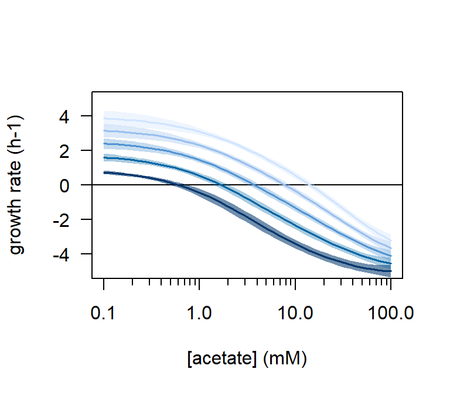

```r
xlab_main <- c(0.1, 1, 10, 100)
xlab_sec <- c(seq(0.2, 0.9, by=0.1), seq(2, 9, by=1), seq(20, 90, by=10))

cols <- sequential_hcl(6, "blues3")

plot_with_ci_4(res_e2[,1,,], "ace_concentration", "Values[v_ace_net]", col=cols[1], xaxt='n', las=1, lwd=1.5, xlim=c(0.1,100), ylim=c(-5,5), log="x", xlab="[acetate] (mM)", ylab="growth rate (h-1)")
abline(h=0)
for (i in seq(1, 5)){
  plot_with_ci_4(res_e2[,i,,], "ace_concentration", "Values[v_ace_net]", col=cols[i], add_to_plot=TRUE, lwd=1.5)

}
axis(side = 1, at = xlab_main, labels = TRUE)
axis(side = 1, at = xlab_sec, labels = FALSE, tcl=-0.3)
```

Save Source data.

```r
data_to_save <- apply(res_e2[,1,,"ace_concentration"], 2, mean)
for (i in seq(5)){
  data_to_save <- cbind(data_to_save,
                        apply(res_e2[,i,,"Values[v_ace_net]"], 2, mean),
                        apply(res_e2[,i,,"Values[v_ace_net]"], 2, sd))
}
colnames(data_to_save) <- c("ace_concentration",
                            "qACE_mean_glc=20%", "qACE_sd_glc=20%",
                            "qACE_mean_glc=40%", "qACE_sd_glc=40%",
                            "qACE_mean_glc=60%", "qACE_sd_glc=60%",
                            "qACE_mean_glc=80%", "qACE_sd_glc=80%",
                            "qACE_mean_glc=100%", "qACE_sd_glc=100%")
write.csv(data_to_save, "results/SourceData/Figure 3/3A/data_3A.csv", quote=FALSE)
```

Plot predicted acetate concentration threshold as function of glycolytic activity.

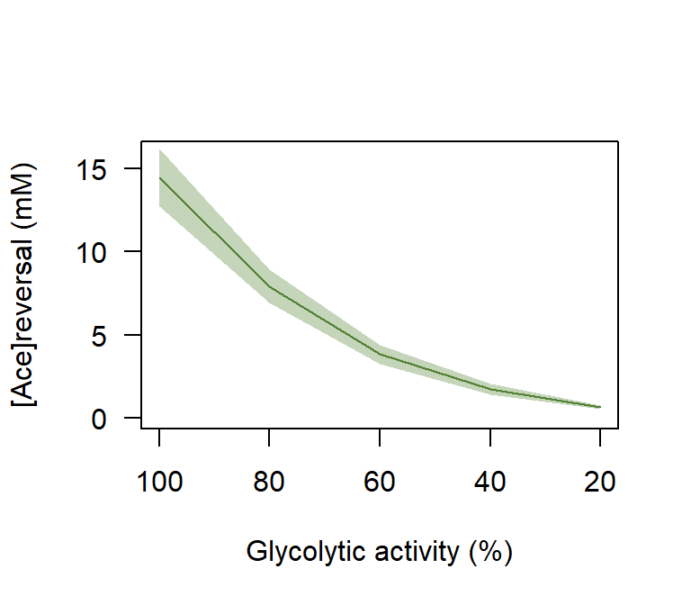

```r
n_glc_steps <- 5
x <- seq(1, n_glc_steps)/n_glc_steps*100

plot(x, rev(apply(res_e2[,,1,"ace_threshold"], 2, mean)), type="l", axes=FALSE, col="#548235", las=1, lwd=1.2, ylim=c(0,16), xlab="Glycolytic activity (%)", ylab="[Ace]reversal (mM)")

axis(1, at = seq(20,100,by=20), labels = paste(seq(100,20, by=-20)), tick = TRUE)
axis(2, tick = TRUE, las=1)
box()

polygon(x=c(x, rev(x)),
          y=c(rev(apply(res_e2[,,1,"ace_threshold"], 2, mean))+rev(apply(res_e2[,,1,"ace_threshold"], 2, sd)), rev(rev(apply(res_e2[,,1,"ace_threshold"], 2, mean))-rev(apply(res_e2[,,1,"ace_threshold"], 2, sd)))),
          col=paste("#548235", "55", sep=""), border=NA)
```

Save Source data.

```r
data_to_save <- apply(res_e2[,,1,"ace_threshold"], 2, mean)

for (i in seq(5)){
  data_to_save <- cbind(data_to_save,
                        apply(res_e2[,,i,"ace_threshold"], 2, mean),
                        apply(res_e2[,,i,"ace_threshold"], 2, sd))
}
colnames(data_to_save) <- c("glycolytic flux",
                            "conc_mean_glc=20%", "conc_sd_glc=20%",
                            "conc_mean_glc=40%", "conc_sd_glc=40%",
                            "conc_mean_glc=60%", "conc_sd_glc=60%",
                            "conc_mean_glc=80%", "conc_sd_glc=80%",
                            "conc_mean_glc=100%", "conc_sd_glc=100%")
write.csv(data_to_save, "results/SourceData/Figure 3/3B/data_3B.csv", quote=FALSE)
```

Experimental validation.

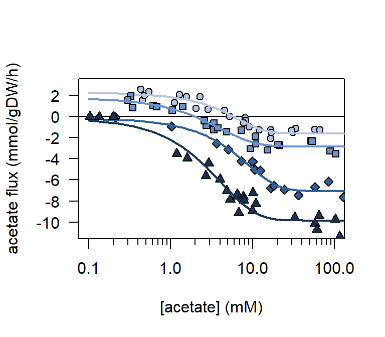

```r
# load experimental data
exp_data <- read.table("data/data_E_coli_K12_MG1655_Figure_3-4.txt", header=TRUE, sep="\t")

# plot acetate flux as function of acetate concentration, at different glycolytic flux (aMG=0, 20, 40 or 100 mM)

  cols <- rev(colorRampPalette(c("#2E75B6", "#D5E3F0"))(4))
  cols <- hcl.colors(6, "Oslo")

  # empty plot
  plot(NA, NA, type="p", log="x", xaxt='n', pch=20, las=1, xlim=c(0.1,100), ylim=c(-11,3), xlab="[acetate] (mM)", ylab="acetate flux (mmol/gDW/h)")
  abline(h=0)

  # aMG = 0 mM
  filter <- (exp_data[,"aMG"]==0)
  col <- cols[2]
  x <- exp_data[filter,"ACE"]
  y <- exp_data[filter,"qACE"]

  points(x, y, bg=col, col="black", pch=21, lwd=1)
  # uncomment the following lines to run the fits, here we just plot the fitted curves
  # note: fitting is not stable, so it might have to be run several times to obtain a correct fit
  #res_fit <- fit_sigmoid(x, y, par_ini_sigmoid, lower_sigmoid, upper_sigmoid)
  #lines(seq(0.1,130,length.out=1000), sim_sigmoid(res_fit$par, seq(0.1,130,length.out=1000)), col=col, lwd=2)
  lines(seq(0.1,130,length.out=1000), sim_sigmoid(c(-0.2460494, -1.5989450, -0.9279984, 6.9209620), seq(0.1,130,length.out=1000)), col=col, lwd=2)

  # aMG = 20 mM
  filter <- (exp_data[,"aMG"]==20)
  col <- cols[3]
  x <- exp_data[filter,"ACE"]
  y <- exp_data[filter,"qACE"]

  points(x, y, bg=col, col="black", pch=22, lwd=1)
  #res_fit <- fit_sigmoid(x, y, par_ini_sigmoid, lower_sigmoid, upper_sigmoid)
  #lines(seq(0.1,130,length.out=1000), sim_sigmoid(res_fit$par, seq(0.1,130,length.out=1000)), col=col, lwd=2)
  lines(seq(0.1,130,length.out=1000), sim_sigmoid(c(-2.454911e-01, -2.840827e+00, 5.006536e+01, 1.000000e+06), seq(0.1,130,length.out=1000)), col=col, lwd=2)

  # aMG = 40 mM
  filter <- (exp_data[,"aMG"]==40)
  col <- cols[4]
  x <- exp_data[filter,"ACE"]
  y <- exp_data[filter,"qACE"]

  points(x, y, bg=col, col="black", pch=23, lwd=1)
  #res_fit <- fit_sigmoid(x, y, par_ini_sigmoid, lower_sigmoid, upper_sigmoid)
  #lines(seq(0.1,130,length.out=1000), sim_sigmoid(res_fit$par, seq(0.1,130,length.out=1000)), col=col, lwd=2)
  lines(seq(0.1,130,length.out=1000), sim_sigmoid(c(-0.1506843, -7.0591207, 3.5268378, 18.6152155), seq(0.1,130,length.out=1000)), col=col, lwd=2)

  # aMG = 100 mM
  filter <- (exp_data[,"aMG"]==100)
  col <- cols[5]
  x <- exp_data[filter,"ACE"]
  y <- exp_data[filter,"qACE"]

  points(x, y, bg=col, col="black", pch=24, lwd=1)
  #res_fit <- fit_sigmoid(x, y, par_ini_sigmoid, lower_sigmoid, upper_sigmoid)
  #lines(seq(0.1,130,length.out=1000), sim_sigmoid(res_fit$par, seq(0.1,130,length.out=1000)), col=col, lwd=2)
  lines(seq(0.1,130,length.out=1000), sim_sigmoid(c(-0.2395667, -9.8451042, 36.7387431, 64514.4364655), seq(0.1,130,length.out=1000)), col=col, lwd=2)

  # add axes
  xlab_main <- c(0.1, 1, 10, 100)
  xlab_sec <- c(seq(0.2, 0.9, by=0.1), seq(2, 9, by=1), seq(20, 90, by=10))
  axis(side = 1, at = xlab_main, labels = TRUE)
  axis(side = 1, at = xlab_sec, labels = FALSE, tcl=-0.3)
```

Save Source data.

```r
write.csv(exp_data, "results/SourceData/Figure 3/3C/data_3C.csv", quote=FALSE)
```

Plot experimental acetate concentration threshold as function of glycolytic activity.

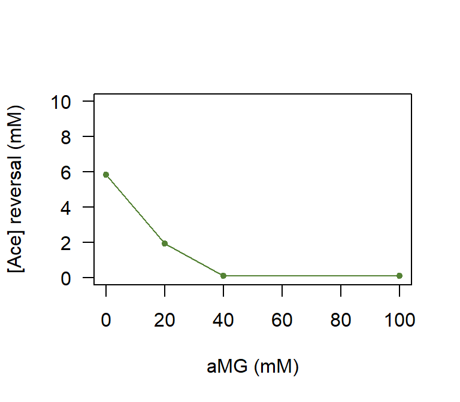

```r
v0 <- get_ace_threshold(sim_sigmoid(c(-0.2460494, -1.5989450, -0.9279984, 6.9209620), seq(0.1,130,length.out=1000)),
                        seq(0.1,130,length.out=1000))
v20 <- get_ace_threshold(sim_sigmoid(c(-2.454911e-01, -2.840827e+00, 5.006536e+01, 1.000000e+06), seq(0.1,130,length.out=1000)),
                        seq(0.1,130,length.out=1000))
v40 <- get_ace_threshold(sim_sigmoid(c(-0.1506843, -7.0591207, 3.5268378, 18.6152155), seq(0.1,130,length.out=1000)),
                        seq(0.1,130,length.out=1000))
v100 <- get_ace_threshold(sim_sigmoid(c(-0.2395667, -9.8451042, 36.7387431, 64514.4364655), seq(0.1,130,length.out=1000)),
                        seq(0.1,130,length.out=1000))

plot(c(0, 20, 40, 100), c(v0, v20, v40, v100), type="l", col="#548235", las=1, lwd=1.2, ylim=c(0,10), xlab="aMG (mM)", ylab="[Ace] reversal (mM)")
points(c(0, 20, 40, 100), c(v0,v20,v40,v100), col="#548235", lwd=1.2, pch=20)
```

Save Source data.

```r
data_to_save <- rbind(c(0, 20, 40, 100), c(v0, v20, v40, v100))
rownames(data_to_save) <- c("aMG", "ace_conc_threshold")

write.csv(exp_data, "results/SourceData/Figure 3/3D/data_3D.csv", quote=FALSE)
```

## 6. Growth rate on glucose as function of 𝛼MG and acetate concentrations

Model predictions.

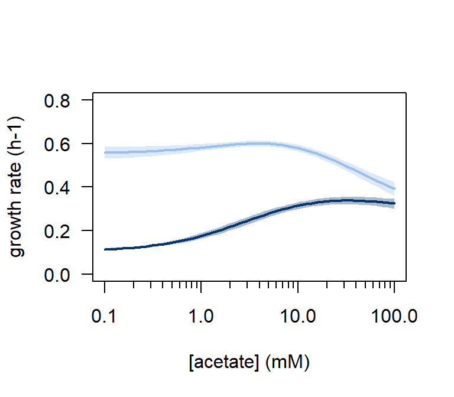

```r
xlab_main <- c(0.1, 1, 10, 100)
xlab_sec <- c(seq(0.2, 0.9, by=0.1), seq(2, 9, by=1), seq(20, 90, by=10))

# growth rate as function of acetate concentration

cols <- sequential_hcl(6, "blues3")

plot_with_ci_4(res_e2[,1,,], "ace_concentration", "Values[v_growth_rate]", col=cols[1], xaxt='n', las=1, lwd=2, xlim=c(0.1,100), ylim=c(0,0.8), log="x", xlab="[acetate] (mM)", ylab="growth rate (h-1)")

plot_with_ci_4(res_e2[,5,,], "ace_concentration", "Values[v_growth_rate]", col=cols[4], add_to_plot=TRUE, lwd=2)

axis(side = 1, at = xlab_main, labels = TRUE)
axis(side = 1, at = xlab_sec, labels = FALSE, tcl=-0.3)
```

Save Source data.

```r
data_to_save <- apply(res_e2[,1,,"ace_concentration"], 2, mean)
for (i in c(1,5)){
  data_to_save <- cbind(data_to_save,
                        apply(res_e2[,i,,"Values[v_growth_rate]"], 2, mean),
                        apply(res_e2[,i,,"Values[v_growth_rate]"], 2, sd))
}
colnames(data_to_save) <- c("ace_concentration",
                            "mu_mean_glc=20%", "mu_sd_glc=20%",
                            "mu_mean_glc=100%", "mu_sd_glc=100%")
write.csv(data_to_save, "results/SourceData/Figure 4/4A/data_4A.csv", quote=FALSE)
```

Plot experimental growth rate as function of acetate concentration at high (0 mM 𝛼MG) or low (100 mM 𝛼MG) glycolytic flux.

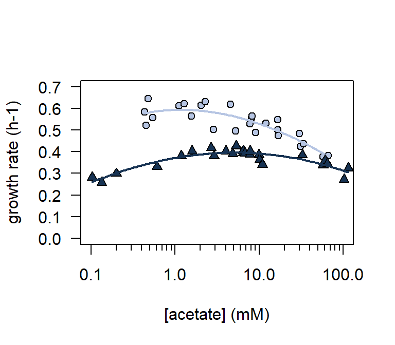

```r
# load experimental data
exp_data <- read.table("data/data_E_coli_K12_MG1655_Figure_3-4.txt", header=TRUE, sep="\t")

# plot growth rate as function of acetate concentration, at high (aMG=0mM) and low (aMG=100mM) glycolytic flux

  cols <- rev(colorRampPalette(c("#2E75B6", "#D5E3F0"))(4))
  cols <- hcl.colors(6, "Oslo")

  # empty plot
  plot(NA, NA, type="p", log="x", col=col, xaxt='n', pch=20, las=1, xlim=c(0.1,100), ylim=c(0, 0.7), xlab="[acetate] (mM)", ylab="growth rate (h-1)")

  # aMG = 0 mM
  filter <- (exp_data[,"aMG"]==0)
  col <- cols[2]
  x <- exp_data[filter,"ACE"]
  y <- exp_data[filter,"mu"]

  points(x, y, bg=cols[2], col="black", pch=21, lwd=1)

  df <- data.frame(x=log10(x), y=y)
  df <- df[order(df$x),]

  model <- lm(y~poly(x,3), data = df)
  #summary(model)
  range_ace <- seq(min(df$x), max(df$x), len=100)
  predy <- predict(model, data.frame(x=range_ace))
  lines(10**range_ace, predy, type="l", col=col, lwd=2)

  # aMG = 100 mM
  filter <- (exp_data[,"aMG"]==100)
  col <- cols[5]
  x <- exp_data[filter,"ACE"]
  y <- exp_data[filter,"mu"]

  points(x, y, bg=col, col="black", pch=24, lwd=1)
  df=data.frame(x=log10(x), y=y)
  df <- df[order(df$x),]

  model = lm(y~poly(x,3), data = df)
  #summary(model)
  i = seq(min(df$x), max(df$x), len=100)       #  x-values for line
  predy = predict(model, data.frame(x=i))
  lines(10**i, predy, type="l", col=col, lwd=2)

  # add axes
  xlab_main <- c(0.1, 1, 10, 100)
  xlab_sec <- c(seq(0.2, 0.9, by=0.1), seq(2, 9, by=1), seq(20, 90, by=10))
  axis(side = 1, at = xlab_main, labels = TRUE)
  axis(side = 1, at = xlab_sec, labels = FALSE, tcl=-0.3)
```

Save Source data.

```r
write.csv(exp_data, "results/SourceData/Figure 4/4B/data_4B.csv", quote=FALSE)
```

## 7. Impact of acetate on growth of WT and mutant strains

### 7.1. Statistical analyses

Load experimental data.

```r
exp_data <- read.table("data/data_E_coli_K12_BW25113_Figure_6-7.txt", header=TRUE, sep="\t")
```

The relative change in growth rate is calculated as:

$$\Delta mu = {\mu_{ace=10} - \mu_{ace=0}
\over \mu_{ace=0}}$$

For each biological replicate, we inoculated media with and without acetate from the same pre-cultivation, and calculated the change of growth rate between these two growth experiments. We carried out at least three independent biological replicate for each condition and calculated the mean ± standard deviation from these replicates. We performed Student t-tests with a null hypothesis that the ratio between the growth rates with and without acetate is 1.

```r
statistical_results <- array(NA, dim=c(30, 11), dimnames=list(NULL, c("carbon source", "strain", "aMG", "ace", "mu_mean", "mu_sd", "n_replicates", "p-val (vs wt, same ace)", "p-val (vs 0 mM ace, same strain)", "relative growth change", "rgc_sd")))

k <- 0
# for each carbon source
for (c_source in unique(exp_data$carbon_source)){
  # for each strain
  for (strain in unique(exp_data$genotype)){
    # for each aMG concentration
    for (aMG in rev(unique(exp_data[((exp_data$genotype == strain) & (exp_data$carbon_source == c_source)), "aMG"]))){
      # for each acetate concentration
      for (ace in unique(exp_data$ACE)){
        # perform all statistical tests (Student t-tests with two-tailed distributions)
        # to compare the different strains/conditions, as detailed below
        k <- k+1
        mu_strain <- exp_data[((exp_data$genotype == strain) & (exp_data$ACE == ace) & (exp_data$carbon_source == c_source) & (exp_data$aMG == aMG)), "mu"]
        mu_mean <- mean(mu_strain)
        mu_sd <- sd(mu_strain)
        #cat("**********************************************\n")
        #cat("Statistical analysis for the following condition:\n")
        #cat("\nstrain: ", strain, ", carbon source: ", c_source , ", [ace]=", ace, "mM, [aMG]=", aMG, "mM\n", sep="")
        #cat("**********************************************\n")
        t_test_factor_strain <- list(p.value=NA)
        if (strain != "wt"){
          n_rep_com <- Reduce(intersect, list(exp_data[((exp_data$genotype == "wt") & (exp_data$ACE == ace) & (exp_data$carbon_source == c_source) & (exp_data$aMG == aMG)), "experiment_number"],
                                              exp_data[((exp_data$genotype == strain) & (exp_data$ACE == ace) & (exp_data$carbon_source == c_source) & (exp_data$aMG == aMG)), "experiment_number"]))
          mu_wt <- exp_data[((exp_data$genotype == "wt") & (exp_data$ACE == ace) & (exp_data$carbon_source == c_source) & (exp_data$aMG == aMG) & (exp_data$experiment_number %in% n_rep_com)), "mu"]
          mu_strain <- exp_data[((exp_data$genotype == strain) & (exp_data$ACE == ace) & (exp_data$carbon_source == c_source) & (exp_data$aMG == aMG) & (exp_data$experiment_number %in% n_rep_com)), "mu"]
          if ((length(mu_wt) > 1) & (length(mu_strain) > 1)){
            t_test_factor_strain <- t.test(mu_wt, mu_strain)
          }

          #cat("\n\nStatistical test:", paste("\n  wt vs ", strain, ", carbon source: ", c_source , ", [ace]=", ace, "mM\n", sep=""), sep="\n")
          #cat("\nwt: ", paste(mu_wt, collapse=", "), "\n", sep="")
          #cat(strain, ": ", paste(mu_strain, collapse=", "), "\n", sep="")
          #print(t_test_factor_strain)
        }
        t_test_factor_ace <- list(p.value=NA)
        relative_growth_change <- NA
        relative_growth_change_sd <- NA
        if (ace == 10){
          mu_no_ace <- exp_data[((exp_data$genotype == strain) & (exp_data$ACE == 0) & (exp_data$carbon_source == c_source) & (exp_data$aMG == aMG)), "mu"]
          mu_ace <- exp_data[((exp_data$genotype == strain) & (exp_data$ACE == ace) & (exp_data$carbon_source == c_source) & (exp_data$aMG == aMG)), "mu"]
          relative_growth_change <- mean(mu_ace/mu_no_ace)-1
          relative_growth_change_sd <- sd(mu_ace/mu_no_ace)
          # here we compared directly the relative change of growth rate induced by 10 mM acetate
          t_test_factor_ace <- t.test(mu_ace/mu_no_ace, mu=1)
          # to compare directly the growth rates in presence and absence of acetate (with paired tests, because for
          # each strain/carbon source cultivations were carried out in parallel with and without acetate), just
          # uncomment the following line (results are similar)
          # t_test_factor_ace <- t.test(mu_ace, mu_no_ace, paired=TRUE)
          #cat("\n\nStatistical test:", paste("\n  strain: ", strain, ", carbon source: ", c_source , ", [ace]=0 mM vs [ace]=10 mM\n", sep=""), sep="\n")
          #cat("relative change of growth rates: ", paste(mu_ace/mu_no_ace-1, collapse=", "), "\n", sep="")
          #print(t_test_factor_ace)
        }
        statistical_results[k, ] <- c(c_source, strain, aMG, ace, mu_mean, mu_sd, length(mu_strain), t_test_factor_strain$p.value, t_test_factor_ace$p.value, relative_growth_change, relative_growth_change_sd)
      }
    }
  }
}
```

Save results.

```r
write.table(statistical_results,"results/StatisticalResults/Statistical_results_glc_gly_gal.tsv", quote=FALSE, sep="\t", row.names=FALSE)
```

### 7.2. Impact of acetate on glucose growth of WT, 𝚫*pgi* and 𝚫*pfkA* strains

Plot relative change in growth rate of the WT strain induced by acetate on glucose.

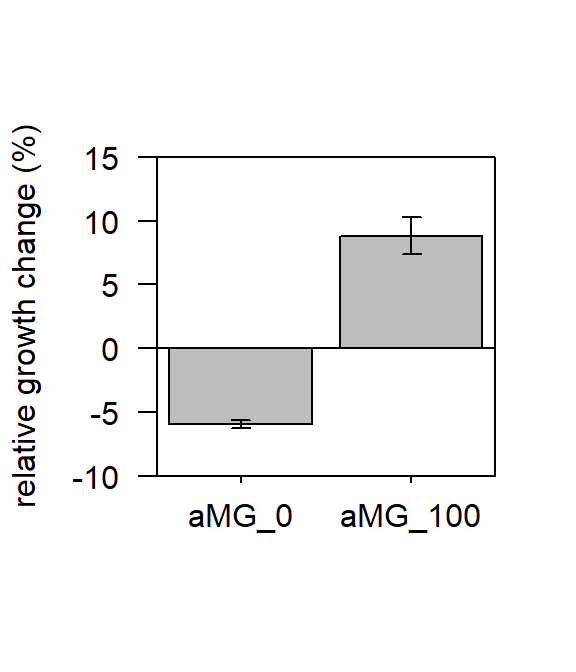

```r
mask <- (is.element(statistical_results[,"carbon source"], c("glucose"))) & (statistical_results[,"ace"] == "10") & (is.element(statistical_results[,"strain"], c("wt")))

data_to_plot <- as.numeric(statistical_results[mask, "relative growth change"])
names(data_to_plot) <- statistical_results[mask, "strain"]
data_sd_to_plot <- as.numeric(statistical_results[mask, "rgc_sd"])
ze_barplot <- barplot(data_to_plot*100, ylim=c(-10,15), beside=TRUE, legend.text=FALSE, las=1, ylab="relative growth change (%)", xaxt='n')
abline(h=0)
error.bar(ze_barplot, data_to_plot*100, data_sd_to_plot*100)
axis(side=1,line=0,at=ze_barplot,labels=c("aMG_0", "aMG_100"),mgp=c(0,0.5,0),tck=-0.02)
box()
```

Save Source data.

```r
data_to_save <- statistical_results[(statistical_results[,"carbon source"] == "glucose"),]

write.table(data_to_save,"results/SourceData/Figure 4/4C/data_4C.tsv", quote=FALSE, sep="\t", row.names=FALSE)
```

Plot relative change in growth rate of the mutant straints induced by acetate on glucose.

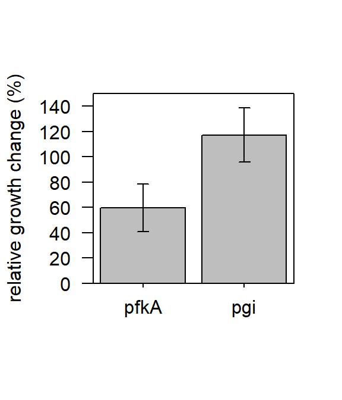

```r
mask <- (is.element(statistical_results[,"carbon source"], c("glucose"))) & (statistical_results[,"ace"] == "10") & (is.element(statistical_results[,"strain"], c("delta_pgi", "delta_pfkA")))

data_to_plot <- as.numeric(statistical_results[mask, "relative growth change"])
names(data_to_plot) <- statistical_results[mask, "strain"]
data_sd_to_plot <- as.numeric(statistical_results[mask, "rgc_sd"])
ze_barplot <- barplot(data_to_plot*100, ylim=c(0,150), beside=TRUE, legend.text=FALSE, las=1, ylab="relative growth change (%)", xaxt='n')
abline(h=0)
error.bar(ze_barplot, data_to_plot*100, data_sd_to_plot*100)
axis(side=1,line=0,at=ze_barplot,labels=c("pfkA", "pgi"),mgp=c(0,0.5,0),tck=-0.02)
box()
```

Save Source data.

```r
write.table(data_to_plot,"results/SourceData/Figure 4/4D/data_4D.tsv", quote=FALSE, sep="\t", row.names=FALSE)
```

### 7.3. Impact of acetate on glucose growth of WT, 𝚫*pta* and 𝚫*acs* strains

Plot data.

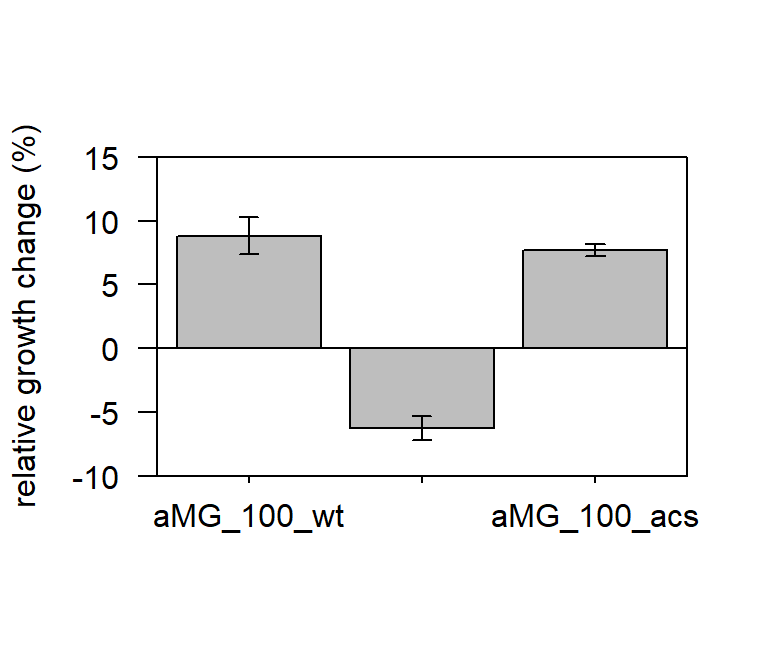

```r
mask <- ((is.element(statistical_results[,"carbon source"], c("glucose"))) & (statistical_results[,"ace"] == "10")) & (statistical_results[,"aMG"] == "100") & (is.element(statistical_results[,"strain"], c("wt", "delta_pta", "delta_acs")))

data_to_plot <- as.numeric(statistical_results[mask, "relative growth change"])
names(data_to_plot) <- statistical_results[mask, "strain"]
data_sd_to_plot <- as.numeric(statistical_results[mask, "rgc_sd"])
ze_barplot <- barplot(data_to_plot*100, ylim=c(-10,15), beside=TRUE, legend.text=FALSE, las=1, ylab="relative growth change (%)", xaxt='n')
abline(h=0)
error.bar(ze_barplot, data_to_plot*100, data_sd_to_plot*100)
axis(side=1,line=0,at=ze_barplot,labels=c("aMG_100_wt","aMG_100_pta","aMG_100_acs"),mgp=c(0,0.5,0),tck=-0.02)
box()
```

Save Source data.

```r
mask <- (is.element(exp_data$carbon_source, c("glucose")) & is.element(exp_data$genotype, c("wt", "delta_pta", "delta_acs")))

write.table(exp_data[mask, ],"results/SourceData/Figure 6/data_6.tsv", quote=FALSE, sep="\t", row.names=FALSE)
```

### 7.4. Impact of acetate on growth of WT, 𝚫*pta* and 𝚫*acs* strains on glycerol and galactose

Relative change in growth rate on glycerol.

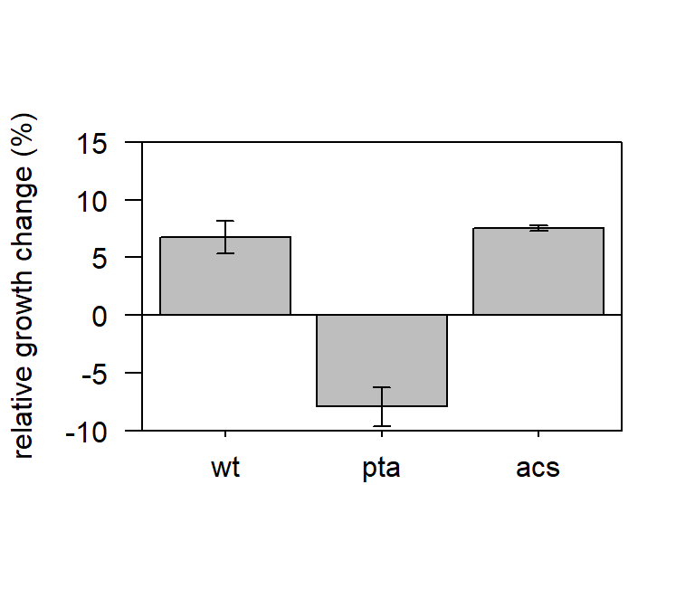

```r
mask <- (is.element(statistical_results[,"carbon source"], c("glycerol"))) & (statistical_results[,"ace"] == "10")

data_to_plot <- as.numeric(statistical_results[mask, "relative growth change"])
names(data_to_plot) <- statistical_results[mask, "strain"]
data_sd_to_plot <- as.numeric(statistical_results[mask, "rgc_sd"])
ze_barplot <- barplot(data_to_plot*100, ylim=c(-10,15), beside=TRUE, legend.text=FALSE, las=1, ylab="relative growth change (%)", xaxt='n')
abline(h=0)
error.bar(ze_barplot, data_to_plot*100, data_sd_to_plot*100)
axis(side=1,line=0,at=ze_barplot,labels=c("wt", "pta","acs"),mgp=c(0,0.5,0),tck=-0.02)
box()
```

Relative change in growth rate on galactose.

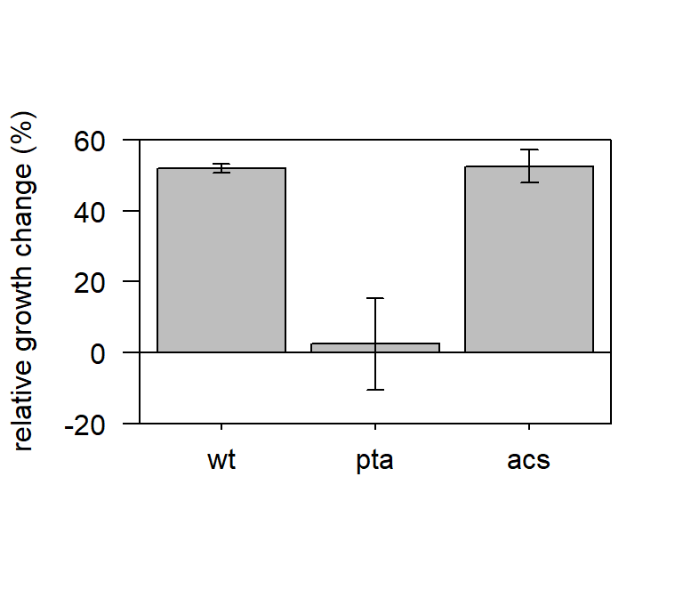

```r
mask <- (is.element(statistical_results[,"carbon source"], c("galactose"))) & (statistical_results[,"ace"] == "10")

data_to_plot <- as.numeric(statistical_results[mask, "relative growth change"])
names(data_to_plot) <- statistical_results[mask, "strain"]
data_sd_to_plot <- as.numeric(statistical_results[mask, "rgc_sd"])
ze_barplot <- barplot(data_to_plot*100, ylim=c(-20,60), beside=TRUE, legend.text=FALSE, las=1, ylab="relative growth change (%)", xaxt='n')
abline(h=0)
error.bar(ze_barplot, data_to_plot*100, data_sd_to_plot*100)
axis(side=1,line=0,at=ze_barplot,labels=c("wt", "pta","acs"),mgp=c(0,0.5,0),tck=-0.02)
box()
```

Save Source data.

```r
mask <- (is.element(exp_data$carbon_source, c("galactose", "glycerol")) & is.element(exp_data$genotype, c("wt", "delta_pta", "delta_acs")))

write.table(exp_data[mask, ],"results/SourceData/Figure 7/data_7.tsv", quote=FALSE, sep="\t", row.names=FALSE)
```

## 8. Change in pH and impact of acetic acid on growth

### 8.1. Change in pH with sodium acetate

Load experimental data.

```r
exp_data <- read.table("data/data_E_coli_K12_BW25113_Figure_EV1.txt", header=TRUE, sep="\t")
```

```r
statistical_results <- array(NA, dim=c(8, 6), dimnames=list(NULL, c("carbon source", "strain", "aMG", "ace", "delta_pH_mean", "delta_pH_sd")))

k <- 0
# for each carbon source
for (c_source in unique(exp_data$carbon_source)){
  # for each strain
  for (strain in unique(exp_data$genotype)){
    # for each aMG concentration
    for (aMG in rev(unique(exp_data[((exp_data$genotype == strain) & (exp_data$carbon_source == c_source)), "aMG"]))){
      # for each acetate concentration
      for (ace in unique(exp_data$ACE)){
        # perform all statistical tests (Student t-tests with two-tailed distributions)
        # to compare the different strains/conditions, as detailed below
        delta_pH <- exp_data[((exp_data$genotype == strain) & (exp_data$ACE == ace) & (exp_data$carbon_source == c_source) & (exp_data$aMG == aMG)), "delta_pH"]
        if (length(delta_pH) > 2){
        k <- k+1
        delta_pH_mean <- mean(delta_pH)
        delta_pH_sd <- sd(delta_pH)

        statistical_results[k, ] <- c(c_source, strain, aMG, ace, delta_pH_mean, delta_pH_sd)

        }
      }
    }
  }
}
```

Save results.

```r
write.table(statistical_results,"results/StatisticalResults/Statistical_results_glc_gly_gal_EV1.tsv", quote=FALSE, sep="\t", row.names=FALSE)
```

Plot change in pH.

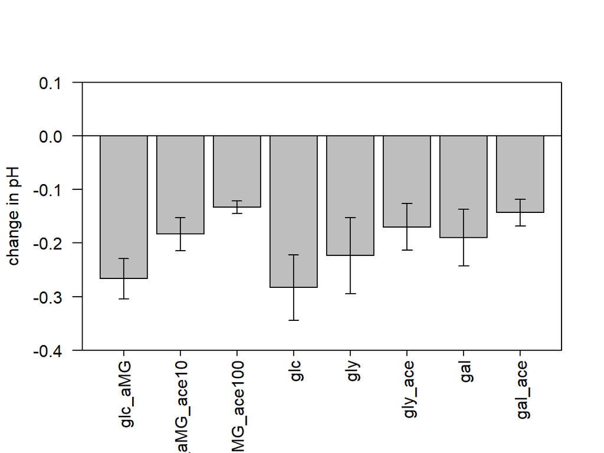

```r
data_to_plot <- as.numeric(statistical_results[, "delta_pH_mean"])

names(data_to_plot) <- paste(statistical_results[, "strain"], statistical_results[, "carbon source"], statistical_results[, "ace"], sep="_")
data_sd_to_plot <- as.numeric(statistical_results[, "delta_pH_sd"])
ze_barplot <- barplot(data_to_plot, ylim=c(-0.4,0.1), beside=TRUE, legend.text=FALSE, las=1, ylab="change in pH", xaxt='n')
abline(h=0)
error.bar(ze_barplot, data_to_plot, data_sd_to_plot)
axis(side=1,line=0,at=ze_barplot,labels=c("glc_aMG", "glc_aMG_ace10", "glc_aMG_ace100", "glc", "gly", "gly_ace", "gal", "gal_ace"),mgp=c(0,0.5,0),tck=-0.02, las=2)
box()
```

### 8.2. Change in pH and growth rate with acetic acid as acetate source

Load experimental data.

```r
exp_data <- read.table("data/data_E_coli_K12_BW25113_Figure_EV2.txt", header=TRUE, sep="\t")
```

```r
statistical_results <- array(NA, dim=c(8, 13), dimnames=list(NULL, c("carbon source", "strain", "aMG", "ace", "mu_mean", "mu_sd", "n_replicates", "p-val (vs wt, same ace)", "p-val (vs 0 mM ace, same strain)", "relative growth change", "rgc_sd", "delta_pH_mean", "delta_pH_sd")))

k <- 0
# for each carbon source
for (c_source in unique(exp_data$carbon_source)){
  # for each strain
  for (strain in unique(exp_data$genotype)){
    # for each aMG concentration
    for (aMG in rev(unique(exp_data[((exp_data$genotype == strain) & (exp_data$carbon_source == c_source)), "aMG"]))){
      # for each acetate concentration
      for (ace in unique(exp_data$ACETIC_ACID)){
        # perform all statistical tests (Student t-tests with two-tailed distributions)
        # to compare the different strains/conditions, as detailed below
        k <- k+1
        mu_strain <- exp_data[((exp_data$genotype == strain) & (exp_data$ACETIC_ACID == ace) & (exp_data$carbon_source == c_source) & (exp_data$aMG == aMG)), "mu"]
        mu_mean <- mean(mu_strain)
        mu_sd <- sd(mu_strain)

        delta_pH <- exp_data[((exp_data$genotype == strain) & (exp_data$ACETIC_ACID == ace) & (exp_data$carbon_source == c_source) & (exp_data$aMG == aMG)), "delta_pH"]
        delta_pH_mean <- mean(delta_pH)
        delta_pH_sd <- sd(delta_pH)
        #cat("**********************************************\n")
        #cat("Statistical analysis for the following condition:\n")
        #cat("\nstrain: ", strain, ", carbon source: ", c_source , ", [ace]=", ace, "mM, [aMG]=", aMG, "mM\n", sep="")
        #cat("**********************************************\n")
        t_test_factor_strain <- list(p.value=NA)
        if (strain != "wt"){
          n_rep_com <- Reduce(intersect, list(exp_data[((exp_data$genotype == "wt") & (exp_data$ACETIC_ACID == ace) & (exp_data$carbon_source == c_source) & (exp_data$aMG == aMG)), "experiment_number"],
                                              exp_data[((exp_data$genotype == strain) & (exp_data$ACETIC_ACID == ace) & (exp_data$carbon_source == c_source) & (exp_data$aMG == aMG)), "experiment_number"]))
          mu_wt <- exp_data[((exp_data$genotype == "wt") & (exp_data$ACETIC_ACID == ace) & (exp_data$carbon_source == c_source) & (exp_data$aMG == aMG) & (exp_data$experiment_number %in% n_rep_com)), "mu"]
          mu_strain <- exp_data[((exp_data$genotype == strain) & (exp_data$ACETIC_ACID == ace) & (exp_data$carbon_source == c_source) & (exp_data$aMG == aMG) & (exp_data$experiment_number %in% n_rep_com)), "mu"]
          if ((length(mu_wt) > 1) & (length(mu_strain) > 1)){
            t_test_factor_strain <- t.test(mu_wt, mu_strain)
          }

          #cat("\n\nStatistical test:", paste("\n  wt vs ", strain, ", carbon source: ", c_source , ", [ace]=", ace, "mM\n", sep=""), sep="\n")
          #cat("\nwt: ", paste(mu_wt, collapse=", "), "\n", sep="")
          #cat(strain, ": ", paste(mu_strain, collapse=", "), "\n", sep="")
          #print(t_test_factor_strain)
        }
        t_test_factor_ace <- list(p.value=NA)
        relative_growth_change <- NA
        relative_growth_change_sd <- NA
        if (ace == 10){

                    n_rep_com <- Reduce(intersect, list(exp_data[((exp_data$genotype == strain) & (exp_data$ACETIC_ACID == ace) & (exp_data$carbon_source == c_source) & (exp_data$aMG == aMG)), "experiment_number"],
                                              exp_data[((exp_data$genotype == strain) & (exp_data$ACETIC_ACID == 0) & (exp_data$carbon_source == c_source) & (exp_data$aMG == aMG)), "experiment_number"]))


          mu_no_ace <- exp_data[((exp_data$genotype == strain) & (exp_data$ACETIC_ACID == 0) & (exp_data$carbon_source == c_source) & (exp_data$aMG == aMG) & (exp_data$experiment_number %in% n_rep_com)), "mu"]
          mu_ace <- exp_data[((exp_data$genotype == strain) & (exp_data$ACETIC_ACID == ace) & (exp_data$carbon_source == c_source) & (exp_data$aMG == aMG) & (exp_data$experiment_number %in% n_rep_com)), "mu"]
          relative_growth_change <- mean(mu_ace/mu_no_ace)-1
          relative_growth_change_sd <- sd(mu_ace/mu_no_ace)
          # here we compared directly the relative change of growth rate induced by 10 mM acetate
          t_test_factor_ace <- t.test(mu_ace/mu_no_ace, mu=1)
          # to compare directly the growth rates in presence and absence of acetate (with paired tests, because for
          # each strain/carbon source cultivations were carried out in parallel with and without acetate), just
          # uncomment the following line (results are similar)
          # t_test_factor_ace <- t.test(mu_ace, mu_no_ace, paired=TRUE)
          #cat("\n\nStatistical test:", paste("\n  strain: ", strain, ", carbon source: ", c_source , ", [ace]=0 mM vs [ace]=10 mM\n", sep=""), sep="\n")
          #cat("relative change of growth rates: ", paste(mu_ace/mu_no_ace-1, collapse=", "), "\n", sep="")
          #print(t_test_factor_ace)
        }
        statistical_results[k, ] <- c(c_source, strain, aMG, ace, mu_mean, mu_sd, length(mu_strain), t_test_factor_strain$p.value, t_test_factor_ace$p.value, relative_growth_change, relative_growth_change_sd, delta_pH_mean, delta_pH_sd)
      }
    }
  }
}
```

Save results.

```r
write.table(statistical_results,"results/StatisticalResults/Statistical_results_glc_gly_gal_EV2.tsv", quote=FALSE, sep="\t", row.names=FALSE)
```

Plot relative change in growth rate induced by acetate.

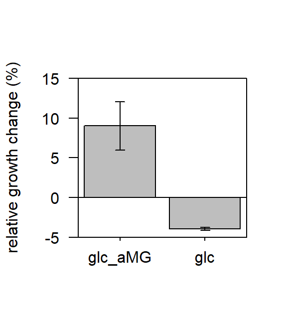

```r
mask <- (statistical_results[,"ace"] == "10") & (statistical_results[,"carbon source"] == "glucose")

data_to_plot <- as.numeric(statistical_results[mask, "relative growth change"])
names(data_to_plot) <- statistical_results[mask, "strain"]
data_sd_to_plot <- as.numeric(statistical_results[mask, "rgc_sd"])
ze_barplot <- barplot(data_to_plot*100, ylim=c(-5,15), beside=TRUE, legend.text=FALSE, las=1, ylab="relative growth change (%)", xaxt='n')
abline(h=0)
error.bar(ze_barplot, data_to_plot*100, data_sd_to_plot*100)
axis(side=1,line=0,at=ze_barplot,labels=c("glc_aMG", "glc"),mgp=c(0,0.5,0),tck=-0.02)
box()
```

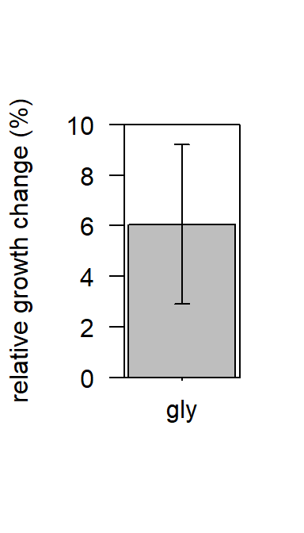

```r
mask <- (statistical_results[,"ace"] == "10") & (statistical_results[,"carbon source"] == "glycerol")

data_to_plot <- as.numeric(statistical_results[mask, "relative growth change"])
names(data_to_plot) <- statistical_results[mask, "strain"]
data_sd_to_plot <- as.numeric(statistical_results[mask, "rgc_sd"])
ze_barplot <- barplot(data_to_plot*100, ylim=c(0,10), beside=TRUE, legend.text=FALSE, las=1, ylab="relative growth change (%)", xaxt='n')
abline(h=0)
error.bar(ze_barplot, data_to_plot*100, data_sd_to_plot*100)
axis(side=1,line=0,at=ze_barplot,labels=c("gly"),mgp=c(0,0.5,0),tck=-0.02)
box()
```

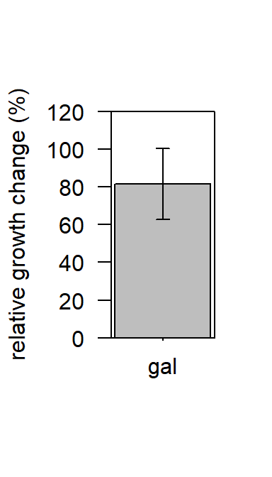

```r
mask <- (statistical_results[,"ace"] == "10") & (statistical_results[,"carbon source"] == "galactose")

data_to_plot <- as.numeric(statistical_results[mask, "relative growth change"])
names(data_to_plot) <- statistical_results[mask, "strain"]
data_sd_to_plot <- as.numeric(statistical_results[mask, "rgc_sd"])
ze_barplot <- barplot(data_to_plot*100, ylim=c(0,120), beside=TRUE, legend.text=FALSE, las=1, ylab="relative growth change (%)", xaxt='n')
abline(h=0)
error.bar(ze_barplot, data_to_plot*100, data_sd_to_plot*100)
axis(side=1,line=0,at=ze_barplot,labels=c("gal"),mgp=c(0,0.5,0),tck=-0.02)
box()
```

Plot change in pH.

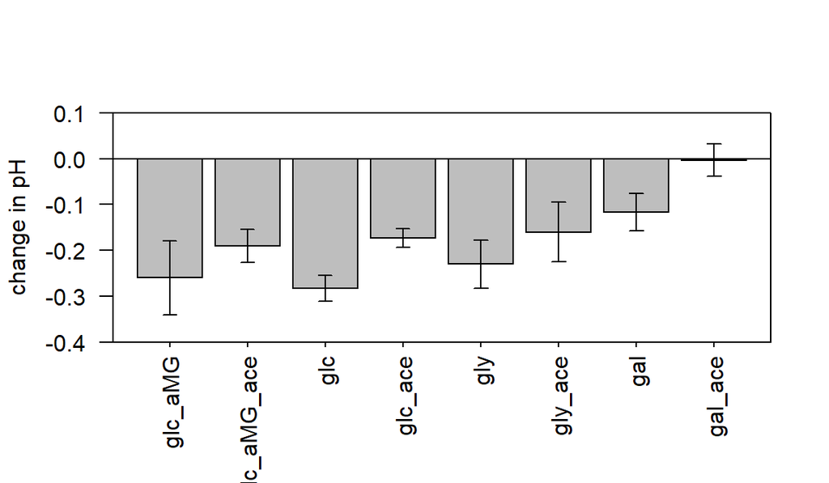

```r
data_to_plot <- as.numeric(statistical_results[, "delta_pH_mean"])

names(data_to_plot) <- paste(statistical_results[, "strain"], statistical_results[, "carbon source"])
data_sd_to_plot <- as.numeric(statistical_results[, "delta_pH_sd"])
ze_barplot <- barplot(data_to_plot, ylim=c(-0.4,0.1), beside=TRUE, legend.text=FALSE, las=1, ylab="change in pH", xaxt='n')
abline(h=0)
error.bar(ze_barplot, data_to_plot, data_sd_to_plot)
axis(side=1,line=0,at=ze_barplot,labels=c("glc_aMG", "glc_aMG_ace", "glc", "glc_ace", "gly", "gly_ace", "gal", "gal_ace"),mgp=c(0,0.5,0),tck=-0.02, las=2)
box()
```